# Data Science Project (Time Series)

## Описание проекта

Компания «Чётенькое такси» собрала исторические данные о заказах такси в аэропортах. Чтобы привлекать больше водителей в период пиковой нагрузки, нужно спрогнозировать количество заказов такси на следующий час. Постройте модель для такого предсказания.

Значение метрики *RMSE* на тестовой выборке должно быть не больше 48.

### Инструкция по выполнению проекта

1. Загрузите данные и выполните их ресемплирование по одному часу.
2. Проанализируйте данные.
3. Обучите разные модели с различными гиперпараметрами. Сделайте тестовую выборку размером 10% от исходных данных.
4. Проверьте данные на тестовой выборке и сделайте выводы.

### Описание данных

Данные лежат в файле `taxi.csv`. Количество заказов находится в столбце '*num_orders*' (от англ. *number of orders*, «число заказов»).

Работу над проектом будем осуществлять в следующем порядке:

### Этап 1. Импорт библиотек, считывание и первичный анализ данных:

1.1. Импорт библиотек, считывание и первичный анализ данных.

### Этап 2. Анализ данных, подготовка новых признаков:

2.1. Анализ данных.

2.1. Подготовка новых признаков.

### Этап 3. Обучение и тестирование моделей, подбор гиперпараметров:

3.1. LinearRegression.

3.2. CatBoost.

3.3. LightGBM.

3.4. RandomForest.

# Этап 1. Импорт библиотек, считывание и первичный анализ данных.

Иморитриуем нужные библиотеки.

```python
import warnings
warnings.filterwarnings('ignore')
import pandas as pd
import numpy as np
import matplotlib.pyplot as plt
import seaborn as sns
from statsmodels.tsa.seasonal import seasonal_decompose
from sklearn.preprocessing import StandardScaler
from sklearn.model_selection import train_test_split
from sklearn.model_selection import TimeSeriesSplit
from sklearn.model_selection import GridSearchCV
from catboost import CatBoostRegressor
from lightgbm import LGBMRegressor
from sklearn.linear_model import LinearRegression
from sklearn.ensemble import RandomForestRegressor
from sklearn.metrics import make_scorer
from sklearn.metrics import mean_squared_error as mse
from sklearn.utils import parallel_backend
```

Считаем набор данных. Чтобы дата из набора данных была считана как дата, а не как object, поле с датой передадим как аргумент параметру parse_dates. Также дата нужна нам как индекс, поэтому это поле передадим как аргумент параметру index_col.

```python
df = pd.read_csv('taxi.csv', parse_dates = ['datetime'], index_col = 'datetime')
```

Для первичного анализа набора данных напишем функцию, принимающую на вход набор данных и выводящую о нём основную интересующую нас информацию: первые 10 строк, общую информацию о наборе данных, размер набора данных, количество дубликатов и пропусков, а также частота встречаемости уникальных значений каждого признака.

```python
def df_info(df):
    print('Первые 10 строк DF')
    display(df.head(10))
    print('Общая информация о DF')
    display(df.info())
    print('Размер df:', df.shape)
    print()
    print('Пропуски в df')
    display(df.isna().sum())
    print('Количество дубликатов в df:', df.duplicated().sum())
    print()
    for col in df.columns:
        print('*** Поле', col + ': уникальные значения ***')
        display(df[col].value_counts())
df_info(df)
```

```
Первые 10 строк DF
```

| datetime | num_orders |
| --- | --- |
| 2018-03-01 00:00:00 | 9 |
| 2018-03-01 00:10:00 | 14 |
| 2018-03-01 00:20:00 | 28 |
| 2018-03-01 00:30:00 | 20 |
| 2018-03-01 00:40:00 | 32 |
| 2018-03-01 00:50:00 | 21 |
| 2018-03-01 01:00:00 | 7 |
| 2018-03-01 01:10:00 | 5 |
| 2018-03-01 01:20:00 | 17 |
| 2018-03-01 01:30:00 | 12 |

```
Общая информация о DF
<class 'pandas.core.frame.DataFrame'>
DatetimeIndex: 26496 entries, 2018-03-01 00:00:00 to 2018-08-31 23:50:00
Data columns (total 1 columns):
 #   Column      Non-Null Count  Dtype
---  ------      --------------  -----
 0   num_orders  26496 non-null  int64
dtypes: int64(1)
memory usage: 414.0 KB
```

```
None
```

```
Размер df: (26496, 1)

Пропуски в df
```

```
num_orders    0
dtype: int64
```

```
Количество дубликатов в df: 26415

*** Поле num_orders: уникальные значения ***
```

```
9     1373
11    1365
12    1317
10    1316
8     1253
      ...
67       1
99       1
90       1
87       1
95       1
Name: num_orders, Length: 81, dtype: int64
```

# Вывод по этапу 1.

На данном этапе были импортированы необходимые библиотеки, а также считан и проанализирован первичный набор данных.

Набор данных представляет собой временной ряд, который описывает количество заказов такси с 2018-03-01 по 2018-08-31 с десятиминутным интервалом.

# 2. Анализ данных, подготовка новых признаков.

## Этап 2.1. Анализ данных.

На данном этапе проанализируем данные и подготовим их к моделированию.

Для начала проверим, упорядочены ли индексы (даты) в порядке возрастания. Используем метод is_monotonic, применим его к индексам набора данных.

```python
print(df.index.is_monotonic)
```

```
True
```

Видим, что индексы (даты) упорядочены по возрастанию.

Далее необходимо сделать ресемплирование данных из минут в часы. Для этого используем функцию resample, параметром укажем значение "1H", что соответствует 1 часу, в качестве агрегирующей функции при группировки объектов внутри интервала укажем sum, так как в 1 час должны суммарно попать все поездки за 6 интервалов по 10 минут.

```python
df = df.resample('1H').sum()
```

Визуализируем временной ряд.

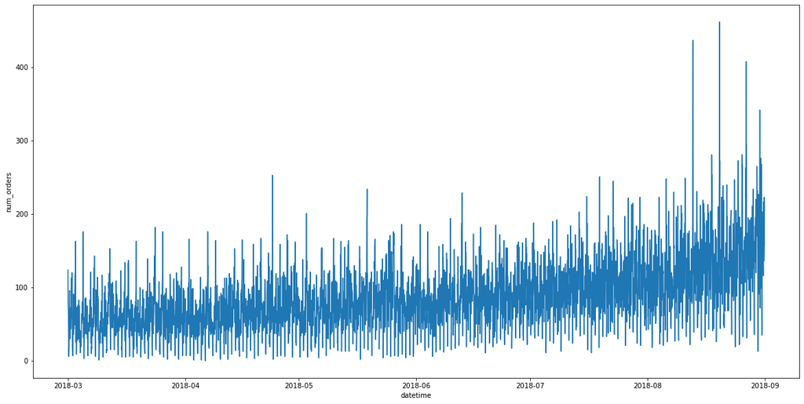

```python
plt.figure(figsize=(20,10))
sns.lineplot(data = df, x=df.index, y='num_orders');
```

Видим, что внутр временного ряда количество поездок сильно колеблется.

Попытаемся сгалидт колебания с помощью метода скользящего среднего.

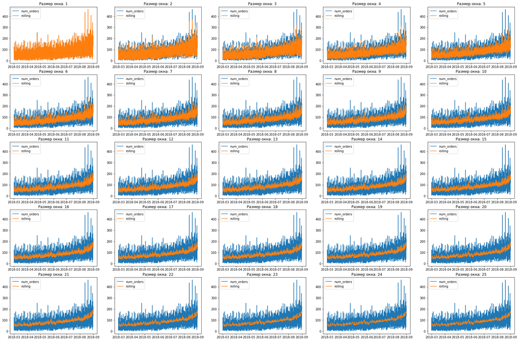

```python
fig, axes = plt.subplots(5, 5, figsize=(30, 20))
windows_size = 1
for i in range(5):
    for j in range(5):
        df['rolling'] = df.rolling(windows_size).mean()
        axes[i, j].plot(df['num_orders'], label='num_orders')
        axes[i, j].plot(df['rolling'], label='rolling')
        axes[i, j].legend()
        axes[i, j].set_title('Размер окна: {}'.format(windows_size))
        windows_size += 1
```

Последовательно в цикле перебирался размер окна от 1 до 25. На полученных графиках синяя лииня - исходный временной ряд, жёлтая - сглаженный временной ряд.

Закономерно видим, что по мере увеличения размера окна колебания сглаженного ряда всё менее и менее заметны.

Проанализируем компоненты временного ряда.

Разложим его на тренд, сезон и ошибку. При анализе сезонной компоненты рассмотрим её динамику за 3 дня.

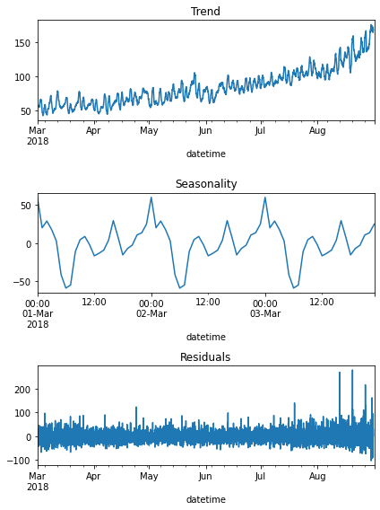

```python
decomposed = seasonal_decompose(df['num_orders'])

plt.figure(figsize=(6, 8))
plt.subplot(311)
decomposed.trend.plot(ax=plt.gca())
plt.title('Trend')
plt.subplot(312)
decomposed.seasonal['2018-03-01':'2018-03-03'].plot(ax=plt.gca())
plt.title('Seasonality')
plt.subplot(313)
decomposed.resid.plot(ax=plt.gca())
plt.title('Residuals')
plt.tight_layout()
```

Видим, что тенденция указывает на поступательный рост числа заказов в такси.

Сезонная компонента имеет суточный характер. Проанализируем сезонность за суточный интервал, чтобы было легче интерпретировать график.

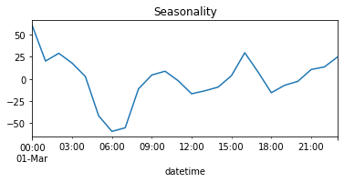

```python
decomposed = seasonal_decompose(df['num_orders'])

plt.figure(figsize=(6, 8))
plt.subplot(312)
decomposed.seasonal['2018-03-01'].plot(ax=plt.gca())
plt.title('Seasonality');
```

Данная сезонность обусловлена спецификой авиабизнеса: в районе 6 утра число заказов минимально (в это время обычно меньше всего рейсов), а больше всего заказов ближе к полуночи (в это время прилетает много рейсов, и, видимо, неудобно добираться на другом транспорте).

Очевидно, что ряд не является стационарным: среднее значение количества заказов со временем увеличивается.

Чтобы прийти к более-менее стационарному ряду, подходящему для прогноза, используем метод сдвига.

```python
df['shift'] = df['num_orders'] - df['num_orders'].shift(fill_value=0)
```

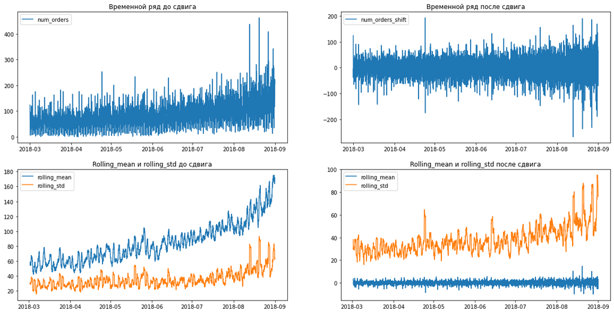

```python
fig, axes = plt.subplots(nrows = 2, ncols = 2, figsize=(20, 10))

axes[0, 0].plot(df['num_orders'], label = 'num_orders')
axes[0, 0].set_title('Временной ряд до сдвига')
axes[0, 0].legend()

axes[0, 1].plot(df['shift'], label = 'num_orders_shift')
axes[0, 1].set_title('Временной ряд после сдвига')
axes[0, 1].legend()

axes[1, 0].plot(df['num_orders'].rolling(25).mean(), label = 'rolling_mean')
axes[1, 0].plot(df['num_orders'].rolling(25).std(), label = 'rolling_std')
axes[1, 0].set_title('Rolling_mean и rolling_std до сдвига')
axes[1, 0].legend()


axes[1, 1].plot(df['shift'].rolling(25).mean(), label = 'rolling_mean')
axes[1, 1].plot(df['shift'].rolling(25).std(), label = 'rolling_std')
axes[1, 1].set_title('Rolling_mean и rolling_std после сдвига')
axes[1, 1].legend();

df.drop(['shift', 'rolling'], axis=1, inplace=True)
```

## Этап 2.2. Подготовка новых признаков.

Напишем функцию для генерирования новых признаков. Функция будет принимать на вход набор данных, максимальную величину сдвига, а также величину окна для сглаживания временного ряда.

На выход функция будет предоставлять набор данных, обогащённый новыми признаками: год, месяц, день и день недели на дату измерения количества заказов, значения количества заказов при сдвиге на величину лага, а также скользящее среднее и скользящее стандартное отклонение временного ряда.

```python
def make_features(df, max_lag, rolling_mean_size):
    df['year'] = df.index.year
    df['month'] = df.index.month
    df['day'] = df.index.day
    df['dayofweek'] = df.index.dayofweek

    for lag in range(1, max_lag + 1):
        df['lag_{}'.format(lag)] = df['num_orders'].shift(lag)

    df['rolling_mean'] = df['num_orders'].shift().rolling(rolling_mean_size).mean()
    df['rolling_std'] = df['num_orders'].shift().rolling(rolling_mean_size).std()
```

Функция написана. Применим функцию к нашему набору данных.

В качестве временного сдвига используем значение 24, так как мы имеем временной ряд с частотой обновления данных в 1 час, окно для сглаживания укажем в размере 15 (значение подобрано эмпирически).

```python
make_features(df, 24, 15)
```

Проверим, что получилось.

```python
df.head(5)
```

| datetime | num_orders | year | month | day | dayofweek | lag_1 | lag_2 | lag_3 | lag_4 | lag_5 | ... | lag_17 | lag_18 | lag_19 | lag_20 | lag_21 | lag_22 | lag_23 | lag_24 | rolling_mean | rolling_std |
| --- | --- | --- | --- | --- | --- | --- | --- | --- | --- | --- | --- | --- | --- | --- | --- | --- | --- | --- | --- | --- | --- |
| 2018-03-01 00:00:00 | 124 | 2018 | 3 | 1 | 3 | NaN | NaN | NaN | NaN | NaN | ... | NaN | NaN | NaN | NaN | NaN | NaN | NaN | NaN | NaN | NaN |
| 2018-03-01 01:00:00 | 85 | 2018 | 3 | 1 | 3 | 124.0 | NaN | NaN | NaN | NaN | ... | NaN | NaN | NaN | NaN | NaN | NaN | NaN | NaN | NaN | NaN |
| 2018-03-01 02:00:00 | 71 | 2018 | 3 | 1 | 3 | 85.0 | 124.0 | NaN | NaN | NaN | ... | NaN | NaN | NaN | NaN | NaN | NaN | NaN | NaN | NaN | NaN |
| 2018-03-01 03:00:00 | 66 | 2018 | 3 | 1 | 3 | 71.0 | 85.0 | 124.0 | NaN | NaN | ... | NaN | NaN | NaN | NaN | NaN | NaN | NaN | NaN | NaN | NaN |
| 2018-03-01 04:00:00 | 43 | 2018 | 3 | 1 | 3 | 66.0 | 71.0 | 85.0 | 124.0 | NaN | ... | NaN | NaN | NaN | NaN | NaN | NaN | NaN | NaN | NaN | NaN |

5 rows × 31 columns

Новые признаки созданы, в ходе их создания появились пропущенные значения. Их нужно удалить.

```python
df = df.dropna()
```

# Вывод по этапу 2.

На данном этапе мы проанализировали временной ряд и создали новые признаки.

Была осуществлена проверка упорядоченности индексов (дат) по возрастанию, визуализирован временной ряд, применена техника скользящего среднего с размером окна от 1 до 25 для сглаживания временного ряда, разложение временного ряда на компоненты (тренд, сезон, ошибка), а также сгенерированы новые признаки: год, месяц, день и день недели на дату измерения количества заказов, значения количества заказов при сдвиге на величину лага, а также скользящее среднее и скользящее стандартное отклонение временного ряда.

# Этап 3. Обучение и тестирование моделей, подбор гиперпараметров.

В рамках данного этапа проттестируем модели LinearRegression, CatBoost, LightGBM и RandomForest.

Сначала выделим признаки и таргет.

```python
features = df.drop('num_orders', axis=1)
target = df['num_orders']
```

Разделим признаки и таргет на тренировочную и тестовую выборки. Так как мы имеем дело с временными рядами, данные при разделении нельзя перемешивать, иначе модель заглянет в будущее. Поэтому передаём параметру shuffle значение False.

Размер тестовой выборки оставим в 10% от общего набора данных.

```python
features_train, features_test, target_train, target_test = train_test_split(features, target, test_size = 0.10,
                                                                            random_state = 42, shuffle = False)
```

Посмотрим, правильно ли получилось. Выведем на экран минимальную и максимальную дату в тренировочном и тестовом наборе данных.

```python
print('Минимальная дата в тренировочной выборке: {}'.format(features_train.index.min()))
print('Максимальная дата в тренировочной выборке: {}'.format(features_train.index.max()))
print('Минимальная дата в тестовой выборке: {}'.format(features_test.index.min()))
print('Максимальная дата в тестовой выборке: {}'.format(features_test.index.max()))
```

```
Минимальная дата в тренировочной выборке: 2018-03-02 00:00:00
Максимальная дата в тренировочной выборке: 2018-08-13 15:00:00
Минимальная дата в тестовой выборке: 2018-08-13 16:00:00
Максимальная дата в тестовой выборке: 2018-08-31 23:00:00
```

## Этап 3.1. LinearRegression.

Протестируем модель линейной регрессии.

Модель линейной регрессии является простой, поэтому для неё не нужно подбирать гиперпараметры.

```python
model = LinearRegression(normalize=True)
model.fit(features_train, target_train)
predictions = model.predict(features_test)
print('RMSE на отложенной выборке для линейной регрессии:', round(mse(target_test, predictions, squared=False), 6))
```

```
RMSE на отложенной выборке для линейной регрессии: 45.471279
```

Видим, что на тестовой выборке модель линейной регрессии обеспечивает RMSE на уровне 45.47 заказов, что является довольно хорошим результатом и соответствует требованию проекта в части значения RMSE не более 48.

Однако ради интереса протестируем другие модели другие модели.

## Этап 3.2. CatBoost.

CatBoost прекрасно тюнит сам себя во время обучения, поэтому не будем ему мешать, а то сделает кусь.

```python
model = CatBoostRegressor(loss_function='RMSE', iterations=1000, random_state=40)
model.fit(features_train, target_train, plot = True, verbose=50)
```

```
Learning rate set to 0.049846
0:	learn: 37.8076189	total: 75.1ms	remaining: 1m 15s
50:	learn: 24.3509893	total: 249ms	remaining: 4.64s
100:	learn: 22.5342126	total: 415ms	remaining: 3.69s
150:	learn: 21.5564060	total: 573ms	remaining: 3.22s
200:	learn: 20.2831774	total: 726ms	remaining: 2.89s
250:	learn: 19.3024103	total: 875ms	remaining: 2.61s
300:	learn: 18.3673808	total: 1.07s	remaining: 2.49s
350:	learn: 17.4969695	total: 1.25s	remaining: 2.3s
400:	learn: 16.7542536	total: 1.41s	remaining: 2.1s
450:	learn: 16.1041968	total: 1.57s	remaining: 1.91s
500:	learn: 15.4672643	total: 1.75s	remaining: 1.74s
550:	learn: 14.8938162	total: 1.91s	remaining: 1.55s
600:	learn: 14.3313608	total: 2.08s	remaining: 1.38s
650:	learn: 13.8135738	total: 2.26s	remaining: 1.21s
700:	learn: 13.4219394	total: 2.45s	remaining: 1.04s
750:	learn: 12.9633561	total: 2.61s	remaining: 865ms
800:	learn: 12.5656172	total: 2.78s	remaining: 691ms
850:	learn: 12.1243247	total: 2.97s	remaining: 520ms
900:	learn: 11.7513537	total: 3.13s	remaining: 344ms
950:	learn: 11.4154383	total: 3.29s	remaining: 170ms
999:	learn: 11.0984709	total: 3.45s	remaining: 0us
```

```
<catboost.core.CatBoostRegressor at 0x1a1d7b1c100>
```

```python
predictions = model.predict(features_test)
print('RMSE на отложенной выборке для CatBoost:', round(mse(target_test, predictions, squared=False), 6))
```

```
RMSE на отложенной выборке для CatBoost: 39.348182
```

CatBoost отработал лучше, чем линейная регрессия: CatBoost предсказывает количество заказов c ошибкой в 39.35 заказов (точнее на 6.12 заказов по сравнению с LinearRegresion). При этом по скорости обучения модели идут практически на одном уровне.

CatBoost также обеспечивает требуемый заказчиком уровнеь точности. Тем не менее, протестируем другие модели.

## Этап 3.3. LightGBM.

Протестируем LightGBM.

Для подбора гиперпараметров будем использовать GridSearchSV. Так как метрика RMSE оптимизируется в сторону минимума, напишем свою метрику оценки, которая будет указывать, что чем меньше значением, тем лучше. Для этого передаём аргумет False параметру greater_is_better.

Также GridSearchSV использует вшитый алгоритм кросс-валидации, основанной на перемешивании объектов. Так как мы работаем с временным рядом, перемешивать объекты нельзя. Чтобы кросс-валидация работала корректно, напишем свою кросс-валидацию.

Используем модуль TimeSeriesSplit, который подходит для реализации концепции кросс-валидации для временных рядов.

Оптимизировать будем 2 параметра: learning_rate (скорость обучения) и num_leaves (количество листьев на дереве).

```python
scorer = make_scorer(mse, greater_is_better=False, squared=False)
cross_val = TimeSeriesSplit(n_splits=5)

model = LGBMRegressor(n_estimators=1000, colsample_bytree=0.6, subsample=0.6, random_state=41)

grid_params = {
    'learning_rate' : [round(i,3) for i in np.arange(0.01, 0.21, 0.010)],
    'num_leaves' : [i for i in range(1, 102, 5)]
}

gs = GridSearchCV(model, grid_params, scoring=scorer, cv=cross_val, verbose=10)
with parallel_backend('threading'):
    gs.fit(features_train, target_train, eval_metric = 'RMSE')
print('Лучшее значение RMSE:', -1 * round(gs.best_score_, 6))
print('Оптимальные значения гиперпараметров:', gs.best_params_)
```

[output not shown]

```
[Parallel(n_jobs=-1)]: Using backend ThreadingBackend with 16 concurrent workers.
```

[output not shown]

```
[Parallel(n_jobs=-1)]: Done   9 tasks      | elapsed:    1.9s
```

[output not shown]

```
[Parallel(n_jobs=-1)]: Done  18 tasks      | elapsed:    4.8s
```

[output not shown]

```
[Parallel(n_jobs=-1)]: Done  29 tasks      | elapsed:   10.0s
```

[output not shown]

```
[Parallel(n_jobs=-1)]: Done  40 tasks      | elapsed:   15.9s
```

[output not shown]

```
[Parallel(n_jobs=-1)]: Done  53 tasks      | elapsed:   24.2s
```

[output not shown]

```
[Parallel(n_jobs=-1)]: Done  66 tasks      | elapsed:   35.2s
```

[output not shown]

```
[Parallel(n_jobs=-1)]: Done  81 tasks      | elapsed:   49.4s
```

[output not shown]

```
[Parallel(n_jobs=-1)]: Done  96 tasks      | elapsed:   58.9s
```

[output not shown]

```
[Parallel(n_jobs=-1)]: Done 113 tasks      | elapsed:  1.1min
```

[output not shown]

```
[Parallel(n_jobs=-1)]: Done 130 tasks      | elapsed:  1.3min
```

[output not shown]

```
[Parallel(n_jobs=-1)]: Done 149 tasks      | elapsed:  1.4min
```

[output not shown]

```
[Parallel(n_jobs=-1)]: Done 168 tasks      | elapsed:  1.7min
```

[output not shown]

```
[Parallel(n_jobs=-1)]: Done 189 tasks      | elapsed:  2.0min
```

[output not shown]

```
[Parallel(n_jobs=-1)]: Done 210 tasks      | elapsed:  2.2min
```

[output not shown]

```
[Parallel(n_jobs=-1)]: Done 233 tasks      | elapsed:  2.4min
```

[output not shown]

```
[Parallel(n_jobs=-1)]: Done 256 tasks      | elapsed:  2.6min
```

[output not shown]

```
[Parallel(n_jobs=-1)]: Done 281 tasks      | elapsed:  2.9min
```

[output not shown]

```
[Parallel(n_jobs=-1)]: Done 306 tasks      | elapsed:  3.2min
```

[output not shown]

```
[Parallel(n_jobs=-1)]: Done 333 tasks      | elapsed:  3.5min
```

[output not shown]

```
[Parallel(n_jobs=-1)]: Done 360 tasks      | elapsed:  3.7min
```

[output not shown]

```
[Parallel(n_jobs=-1)]: Done 389 tasks      | elapsed:  4.1min
```

[output not shown]

```
[Parallel(n_jobs=-1)]: Done 418 tasks      | elapsed:  4.5min
```

[output not shown]

[output not shown]

[output not shown]

```
[Parallel(n_jobs=-1)]: Done 480 tasks      | elapsed:  5.1min
```

[output not shown]

[output cut: 15 more lines]

[output not shown]

```
[Parallel(n_jobs=-1)]: Done 513 tasks      | elapsed:  5.6min
```

[output not shown]

```
[Parallel(n_jobs=-1)]: Done 546 tasks      | elapsed:  5.9min
```

[output not shown]

[output cut: 15 more lines]

[output not shown]

```
[Parallel(n_jobs=-1)]: Done 581 tasks      | elapsed:  6.3min
```

[output not shown]

[output cut: 23 more lines]

[output not shown]

```
[Parallel(n_jobs=-1)]: Done 616 tasks      | elapsed:  6.8min
```

[output not shown]

[output cut: 11 more lines]

[output not shown]

```
[Parallel(n_jobs=-1)]: Done 653 tasks      | elapsed:  7.1min
```

[output not shown]

[output cut: 19 more lines]

[output not shown]

```
[Parallel(n_jobs=-1)]: Done 690 tasks      | elapsed:  7.5min
```

[output not shown]

[output cut: 23 more lines]

[output not shown]

```
[Parallel(n_jobs=-1)]: Done 729 tasks      | elapsed:  8.0min
```

[output not shown]

[output cut: 23 more lines]

[output not shown]

```
[Parallel(n_jobs=-1)]: Done 768 tasks      | elapsed:  8.3min
```

[output not shown]

[output cut: 27 more lines]

[output not shown]

```
[Parallel(n_jobs=-1)]: Done 809 tasks      | elapsed:  8.8min
```

[output not shown]

[output cut: 27 more lines]

[output not shown]

```
[Parallel(n_jobs=-1)]: Done 850 tasks      | elapsed:  9.3min
```

[output not shown]

[output cut: 31 more lines]

[output not shown]

```
[Parallel(n_jobs=-1)]: Done 893 tasks      | elapsed:  9.7min
```

[output not shown]

[output cut: 31 more lines]

[output not shown]

```
[Parallel(n_jobs=-1)]: Done 936 tasks      | elapsed: 10.3min
```

[output not shown]

[output cut: 35 more lines]

[output not shown]

```
[Parallel(n_jobs=-1)]: Done 981 tasks      | elapsed: 10.7min
```

[output not shown]

[output cut: 35 more lines]

[output not shown]

```
[Parallel(n_jobs=-1)]: Done 1026 tasks      | elapsed: 11.3min
```

[output not shown]

[output cut: 39 more lines]

[output not shown]

```
[Parallel(n_jobs=-1)]: Done 1073 tasks      | elapsed: 11.7min
```

[output not shown]

[output cut: 39 more lines]

[output not shown]

```
[Parallel(n_jobs=-1)]: Done 1120 tasks      | elapsed: 12.3min
```

[output not shown]

[output cut: 43 more lines]

[output not shown]

```
[Parallel(n_jobs=-1)]: Done 1169 tasks      | elapsed: 12.8min
```

[output not shown]

[output cut: 43 more lines]

[output not shown]

```
[Parallel(n_jobs=-1)]: Done 1218 tasks      | elapsed: 13.4min
```

[output not shown]

[output cut: 47 more lines]

[output not shown]

```
[Parallel(n_jobs=-1)]: Done 1269 tasks      | elapsed: 14.0min
```

[output not shown]

[output cut: 47 more lines]

[output not shown]

```
[Parallel(n_jobs=-1)]: Done 1320 tasks      | elapsed: 14.5min
```

[output not shown]

[output cut: 51 more lines]

[output not shown]

```
[Parallel(n_jobs=-1)]: Done 1373 tasks      | elapsed: 15.1min
```

[output not shown]

[output cut: 52 more lines]

[output not shown]

```
[Parallel(n_jobs=-1)]: Done 1426 tasks      | elapsed: 15.7min
```

[output not shown]

[output cut: 54 more lines]

[output not shown]

```
[Parallel(n_jobs=-1)]: Done 1481 tasks      | elapsed: 16.3min
```

[output not shown]

[output cut: 55 more lines]

[output not shown]

```
[Parallel(n_jobs=-1)]: Done 1536 tasks      | elapsed: 16.9min
```

[output not shown]

[output cut: 59 more lines]

[output not shown]

```
[Parallel(n_jobs=-1)]: Done 1593 tasks      | elapsed: 17.5min
```

[output not shown]

[output cut: 59 more lines]

[output not shown]

```
[Parallel(n_jobs=-1)]: Done 1650 tasks      | elapsed: 18.2min
```

[output not shown]

[output cut: 63 more lines]

[output not shown]

```
[Parallel(n_jobs=-1)]: Done 1709 tasks      | elapsed: 18.7min
```

[output not shown]

[output cut: 63 more lines]

[output not shown]

```
[Parallel(n_jobs=-1)]: Done 1768 tasks      | elapsed: 19.5min
```

[output not shown]

[output cut: 67 more lines]

[output not shown]

```
[Parallel(n_jobs=-1)]: Done 1829 tasks      | elapsed: 20.0min
```

[output not shown]

[output cut: 67 more lines]

[output not shown]

```
[Parallel(n_jobs=-1)]: Done 1890 tasks      | elapsed: 20.8min
```

[output not shown]

[output cut: 71 more lines]

[output not shown]

```
[Parallel(n_jobs=-1)]: Done 1953 tasks      | elapsed: 21.4min
```

[output not shown]

[output cut: 71 more lines]

[output not shown]

```
[Parallel(n_jobs=-1)]: Done 2016 tasks      | elapsed: 22.2min
```

[output not shown]

[output cut: 97 more lines]

[output not shown]

```
[Parallel(n_jobs=-1)]: Done 2100 out of 2100 | elapsed: 23.2min finished
```

```
Лучшее значение RMSE: 25.362302
Оптимальные значения гиперпараметров: {'learning_rate': 0.01, 'num_leaves': 16}
```

LightGBM на тренировочной выборке с кросс-валидацией по 5 фолдам обеспечивает RMSE на уровне 25.36 заказов при скорости обучения 0.01 и количестве 16 листьев на дереве.

Обучим финальную модель, используя оптимальные значения гиперпараметров.

```python
model = LGBMRegressor(n_estimators=1000, colsample_bytree=0.6, subsample=0.6,
                      learning_rate=gs.best_params_['learning_rate'],
                      num_leaves=gs.best_params_['num_leaves'], random_state=34)

model.fit(features_train, target_train, eval_metric='RMSE')
predictions = model.predict(features_test)

print('RMSE на отложенной выборке для LightGBM: {:.6f} заказов'.format(mse(target_test, predictions, squared=False)))
```

```
RMSE на отложенной выборке для LightGBM: 41.303169 заказов
```

## Этап 3.4. RandomForest.

Наконец, попробуем модель RandomForest.

Для подбора гиперпараметров также будем использовать GridSearchSV. Условия её использования аналогичны условиям использования агоритма при тестировании LightGBM.

Оптимизировать будем параметры n_estimators (количество деревьев) и max_depth (глубина дерева).

```python
scorer = make_scorer(mse, greater_is_better=False, squared=False)
cross_val = TimeSeriesSplit(n_splits=5)

model = RandomForestRegressor(random_state=34)

params = {
    'n_estimators' : [i for i in range(1, 101, 5)],
    'max_depth' : [i for i in range(1, 20, 1)]
}

gs = GridSearchCV(model, params, cv=cross_val, scoring=scorer, verbose=10)
with parallel_backend('threading'):
    gs.fit(features_train, target_train)
print('Лучшее значение MSE:', -1 * round(gs.best_score_, 6))
print('Оптимальные значения гиперпараметров:', gs.best_params_)
```

[output not shown]

```
[Parallel(n_jobs=-1)]: Using backend ThreadingBackend with 16 concurrent workers.
```

[output not shown]

```
[Parallel(n_jobs=-1)]: Done   9 tasks      | elapsed:    0.5s
```

[output not shown]

```
[Parallel(n_jobs=-1)]: Done  18 tasks      | elapsed:    1.1s
```

[output not shown]

```
[Parallel(n_jobs=-1)]: Done  29 tasks      | elapsed:    1.9s
```

[output not shown]

```
[Parallel(n_jobs=-1)]: Done  40 tasks      | elapsed:    3.1s
```

[output not shown]

```
[Parallel(n_jobs=-1)]: Done  53 tasks      | elapsed:    4.6s
```

[output not shown]

```
[Parallel(n_jobs=-1)]: Done  66 tasks      | elapsed:    6.7s
```

[output not shown]

```
[Parallel(n_jobs=-1)]: Done  81 tasks      | elapsed:    9.4s
```

[output not shown]

```
[Parallel(n_jobs=-1)]: Done  96 tasks      | elapsed:   10.9s
```

[output not shown]

```
[Parallel(n_jobs=-1)]: Done 113 tasks      | elapsed:   12.1s
```

[output not shown]

```
[Parallel(n_jobs=-1)]: Done 130 tasks      | elapsed:   13.3s
```

[output not shown]

```
[Parallel(n_jobs=-1)]: Done 149 tasks      | elapsed:   15.1s
```

[output not shown]

```
[Parallel(n_jobs=-1)]: Done 168 tasks      | elapsed:   17.4s
```

[output not shown]